# reproduction paper ordinal modeling

Nicolás Sánchez-Fuenzlida

14-11-2022

```r
# Packages
if (!require('pacman', quietly = TRUE)) install.packages('pacman'); library('pacman', quietly = TRUE)
p_load(here, readr, BayesFactor, magrittr, dplyr, purrr, stringr, ggplot2)
```

```r
set.seed(seed = 12345)
```

## Data

```r
dat <-
  read_csv(here('data/processed/rep_bias_and_reproduction.csv')) %>%
  mutate(cond_code = paste0(substr(bias_source, 1, 2), substr(bias_direction, 1, 2)))
```

### Filter data

```r
# True keeps discrimination data.
# False keeps reproduction data
analyze_decision <- TRUE

if (analyze_decision) {
  task_name <- 'decision'
  dat <-
    dat %>%
    select(-c(rep,d)) %>%
    rename(value = ccrit)
} else {
  task_name <- 'reproduction'
  dat <-
    dat %>%
    select(-c(ccrit,d)) %>%
    rename(value = rep)
}

# Sort data
dat <- dat %>%
  arrange(bias_source, bias_direction)

# Count subjects
dat %>%
  group_by(bias_source) %>%
  select(bias_source, participant) %>%
  distinct() %>%
  summarise(count = n())
```

```
## # A tibble: 3 × 2
##   bias_source count
##   <chr>       <int>
## 1 baserate       62
## 2 mullerlyer     28
## 3 payoff         47
```

## Function

```r
# Gets unconstrained comparison BF and posterior samples
get_bf_samp <- function(y, x, gMap, rscale, no_iter, filter_iter) {

  # Compute BF
  out_bf <- nWayAOV(y, x, gMap, rscale = rep(rscale, length(unique(gMap))))
  # Sample posterior
  out_samp <- nWayAOV(y, x, gMap, rscale = rep(rscale, length(unique(gMap)))
                      , posterior = TRUE, iterations = no_iter)
  # Filter first n% of the iterations
  out_samp <- out_samp[(nrow(out_samp) * filter_iter) : nrow(out_samp),]
  # return bf and sample
  return(list(out_bf, out_samp))
}

# Make contrast image to check that coding looks fine
make_condition_contrast_image <- function(contrast) {

  contrast %>%
    as_tibble() %>%
    select(matches('x[0-9]{1}$', perl = TRUE)) %>%
    as.matrix() %>%
    t() %>%
    image()

}

# Get gMap based on contrast columns

get_gMap <- function(contrast) {
  # This gMap is used if no sub-effect
  gMap <- 1:(length(grep('x[0-9]{1}$', colnames(contrast), value = TRUE)))
  # Include participant contrast to gMap
  gMap <- c(rep(0, length(grep('x[0-9]{2,3}$', colnames(contrast), value = TRUE))), gMap)
  return(gMap)
}

## Contrast functions ---------

get_id_contrast <- function(id_col) {

  # get unique ids (there are two per participant)
  unique_ids <- id_col %>% pull(id) %>% unique()
  # make id contrast matrix
  id_contrast <-

    map2(unique_ids, seq(length(unique_ids)),
         ~ id_col %>%
           transmute(as.integer(id == .x)) %>%
           # The column names start from 10 because the first 10
           # names are reserved for the contrast indicating the
           # bias condition.
           set_names(paste0('x', .y + 10))
    ) %>%
    bind_cols()

  # Convert to matrix to combine with other
  # contrast matrices
  id_contrast <-
    as.matrix(id_contrast)

  return(id_contrast)

}

get_contrast_A <- function(dat) {

  # Muller-Lyer
  x1 <- ifelse(dat$cond_code %in% c("mulo", "mush"), 1, 0) # ML intercept
  x2 <- ifelse(dat$cond_code == "mulo", .5,
               ifelse(dat$cond_code == "mush", -.5, 0))    # ML bias direction effect
  # Base rate
  x3 <- ifelse(dat$cond_code %in% c("balo", "bash"), 1, 0) # BR intercept
  x4 <- ifelse(dat$cond_code == "balo", .5,
               ifelse(dat$cond_code == "bash", -.5, 0))    # BR bias direction effect
  # Payoff
  # The payoff condition is used as the intercept so it's not indicated in
  # contrast matrix and instead is always the 'mu' column in the sample data.
  x5 <- ifelse(dat$cond_code == "palo", .5,
               ifelse(dat$cond_code == "pash", -.5, 0))    # PO bias direction effect

  # Combine all contrast columns into one matrix
  X_a <- cbind(x1, x2, x3, x4, x5)

  # Add id contrast
  X_a <-
    cbind(
      id_contrast,
      X_a)

  return(X_a)
}

get_contrast_B <- function(dat) {

  # Muller-Lyer
  x1 <- ifelse(dat$cond_code %in% c("mulo", "mush"), 1, 0) # ML intercept
  # Base rate
  x2 <- ifelse(dat$cond_code %in% c("balo", "bash"), 1, 0) # BR intercept
  # Bias direction irrespective of bias source
  x3 <- ifelse(dat$bias_direction == 'long', .5,       # bias direction effect
               ifelse(dat$bias_direction == 'short', -.5, 0))

  # Combine all contrast columns into one matrix
  X_b <- cbind(x1, x2, x3)

  # Add id contrast
  X_b <-
    cbind(
      id_contrast,
      X_b)

  return(X_b)
}

get_contrast_C <- function(dat) {

  # Muller-Lyer
  x1 <- ifelse(dat$cond_code %in% c("mulo", "mush"), 1, 0) # ML intercept
  # Base rate
  x2 <- ifelse(dat$cond_code %in% c("balo", "bash"), 1, 0) # BR intercept
  # Muller-Lyer & Base rate bias direction
  x3 <- ifelse(dat$cond_code %in% c("mulo", "balo"), .5,
               ifelse(dat$cond_code %in% c("mush", "bash"), -.5, 0)) # bias direction effect
  # Payoff
  # The payoff condition is used as the intercept so it's not indicated in
  # contrast matrix and instead is always the 'mu' column in the sample data.
  x4 <- ifelse(dat$cond_code == "palo", .5,
               ifelse(dat$cond_code == "pash", -.5, 0))    # PO bias direction effect

  # Combine all contrast columns into one matrix
  X_c <- cbind(x1, x2, x3, x4)

  # Add id contrast
  X_c <-
    cbind(
      id_contrast,
      X_c)

  return(X_c)
}

get_contrast_D <- function(dat) {

  # Muller-Lyer
  x1 <- ifelse(dat$cond_code %in% c("mulo", "mush"), 1, 0) # ML intercept
  # Muller-Lyer & Payoff bias direction
  x2 <- ifelse(dat$cond_code %in% c("mulo", "palo"), .5,
               ifelse(dat$cond_code %in% c("mush", "pash"), -.5, 0)) # bias direction effect

  # Base rate
  x3 <- ifelse(dat$cond_code %in% c("balo", "bash"), 1, 0) # BR intercept
  x4 <- ifelse(dat$cond_code == "balo", .5,
               ifelse(dat$cond_code == "bash", -.5, 0))    # BR bias direction effect

  # Combine all contrast columns into one matrix
  X_d <- cbind(x1, x2, x3, x4)

  # Add id contrast
  X_d <-
    cbind(
      id_contrast,
      X_d)

  return(X_d)
}

get_contrast_E <- function(dat) {

  # Muller-Lyer
  x1 <- ifelse(dat$cond_code %in% c("mulo", "mush"), 1, 0) # ML intercept
  x2 <- ifelse(dat$cond_code == "mulo", .5,
               ifelse(dat$cond_code == "mush", -.5, 0))    # ML bias direction effect
  # Base rate
  x3 <- ifelse(dat$cond_code %in% c("balo", "bash"), 1, 0) # BR intercept

  # Combine all contrast columns into one matrix
  X_e <- cbind(x1, x2, x3)

  # Add id contrast
  X_e <-
    cbind(
      id_contrast,
      X_e)

  return(X_e)
}

get_contrast_F <- function(dat) {

  # Muller-Lyer
  x1 <- ifelse(dat$cond_code %in% c("mulo", "mush"), 1, 0) # ML intercept
  # Base rate
  x2 <- ifelse(dat$cond_code %in% c("balo", "bash"), 1, 0) # BR intercept

  # Combine all contrast columns into one matrix
  X_f <- cbind(x1, x2)

  # Add id contrast
  X_f <-
    cbind(
      id_contrast,
      X_f)

  return(X_f)
}

get_contrast_G <- function(dat) {

  # Muller-Lyer
  x1 <- ifelse(dat$cond_code %in% c("mulo", "mush"), 1, 0) # ML intercept
  x2 <- ifelse(dat$cond_code == "mulo", .5,
               ifelse(dat$cond_code == "mush", -.5, 0))    # ML bias direction effect
  # Base rate
  x3 <- ifelse(dat$cond_code %in% c("balo", "bash"), 1, 0) # BR intercept
  x4 <- ifelse(dat$cond_code == "balo", .5,
               ifelse(dat$cond_code == "bash", -.5, 0))    # BR bias direction effect

  # Combine all contrast columns into one matrix
  X_g <- cbind(x1, x2, x3, x4)

  # Add id contrast
  X_g <-
    cbind(
      id_contrast,
      X_g)

  return(X_g)
}

get_contrast_H <- function(dat) {

  # Muller-Lyer
  x1 <- ifelse(dat$cond_code %in% c("mulo", "mush"), 1, 0) # ML intercept
  x2 <- ifelse(dat$cond_code == "mulo", .5,
               ifelse(dat$cond_code == "mush", -.5, 0))    # ML bias direction effect
  # Base rate
  x3 <- ifelse(dat$cond_code %in% c("balo", "bash"), 1, 0) # BR intercept
  # Payoff
  # The payoff condition is used as the intercept so it's not indicated in
  # contrast matrix and instead is always the 'mu' column in the sample data.
  x4 <- ifelse(dat$cond_code == "palo", .5,
               ifelse(dat$cond_code == "pash", -.5, 0))    # PO bias direction effect


  # Combine all contrast columns into one matrix
  X_h <- cbind(x1, x2, x3, x4)

  # Add id contrast
  X_h <-
    cbind(
      id_contrast,
      X_h)

  return(X_h)
}


get_contrast_I <- function(dat) {

  # Muller-Lyer
  x1 <- ifelse(dat$cond_code %in% c("mulo", "mush"), 1, 0) # ML intercept

  x2 <- ifelse(dat$cond_code %in% c("balo", "bash"), 1, 0) # BR intercept
  x3 <- ifelse(dat$cond_code == "balo", .5,
               ifelse(dat$cond_code == "bash", -.5, 0))    # BR bias direction effect
  # Payoff
  # The payoff condition is used as the intercept so it's not indicated in
  # contrast matrix and instead is always the 'mu' column in the sample data.
  x4 <- ifelse(dat$cond_code == "palo", .5,
               ifelse(dat$cond_code == "pash", -.5, 0))    # PO bias direction effect


  # Combine all contrast columns into one matrix
  X_i <- cbind(x1, x2, x3, x4)

  # Add id contrast
  X_i <-
    cbind(
      id_contrast,
      X_i)

  return(X_i)
}

get_contrast_J <- function(dat) {

  # Muller-Lyer
  x1 <- ifelse(dat$cond_code %in% c("mulo", "mush"), 1, 0) # ML intercept
  # Base rate
  x2 <- ifelse(dat$cond_code %in% c("balo", "bash"), 1, 0) # BR intercept
  # Payoff
  x3 <- ifelse(dat$cond_code == "palo", .5,
               ifelse(dat$cond_code == "pash", -.5, 0))    # ML bias direction effect

  # Combine all contrast columns into one matrix
  X_j <- cbind(x1, x2, x3)

  # Add id contrast
  X_j <-
    cbind(
      id_contrast,
      X_j)

  return(X_j)
}

get_contrast_K <- function(dat) {

  # Muller-Lyer
  x1 <- ifelse(dat$cond_code %in% c("mulo", "mush"), 1, 0) # ML intercept
  # Base rate
  x2 <- ifelse(dat$cond_code %in% c("balo", "bash"), 1, 0) # BR intercept
  x3 <- ifelse(dat$cond_code == "balo", .5,
               ifelse(dat$cond_code == "bash", -.5, 0))    # ML bias direction effect

  # Combine all contrast columns into one matrix
  X_k <- cbind(x1, x2, x3)

  # Add id contrast
  X_k <-
    cbind(
      id_contrast,
      X_k)

  return(X_k)
}

get_contrast_L <- function(dat) {

  # Muller-Lyer
  x1 <- ifelse(dat$cond_code %in% c("mulo", "mush"), 1, 0) # ML intercept
  # Muller-Lyer bias direction
  x2 <- ifelse(dat$cond_code == "mulo", .5,
               ifelse(dat$cond_code == "mush", -.5, 0))    # BR bias direction effect
  # Base rate
  x3 <- ifelse(dat$cond_code %in% c("balo", "bash"), 1, 0) # BR intercept
  # Base rate & Payoff bias direction
  x4 <- ifelse(dat$cond_code %in% c("balo", "palo"), .5,
               ifelse(dat$cond_code %in% c("bash", "pash"), -.5, 0)) # bias direction effect



  # Combine all contrast columns into one matrix
  X_l <- cbind(x1, x2, x3, x4)

  # Add id contrast
  X_l <-
    cbind(
      id_contrast,
      X_l)

  return(X_l)
}
```

## Bayes sampling

### Settings

Same settings for all models.

```r
# Iteration N
no_iter <- 5000
filter_iter <- .1
# R scale (effect size)
r <- .707
```

## Contrast matrices

### Subject contrast

This chunk creates a contrast matrix to indicate to which subject each observation belongs.

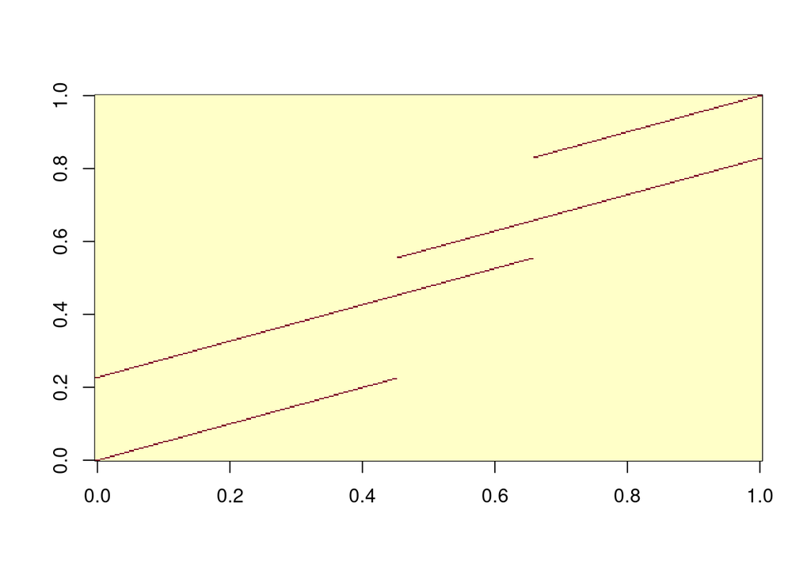

```r
# Run analysis including subject contrast?
include_id_contrast = TRUE

# Get id contrast matrix
id_contrast <- get_id_contrast(dat %>% select(participant) %>% rename(id=participant))

# Display matrix
image(t(id_contrast))
```

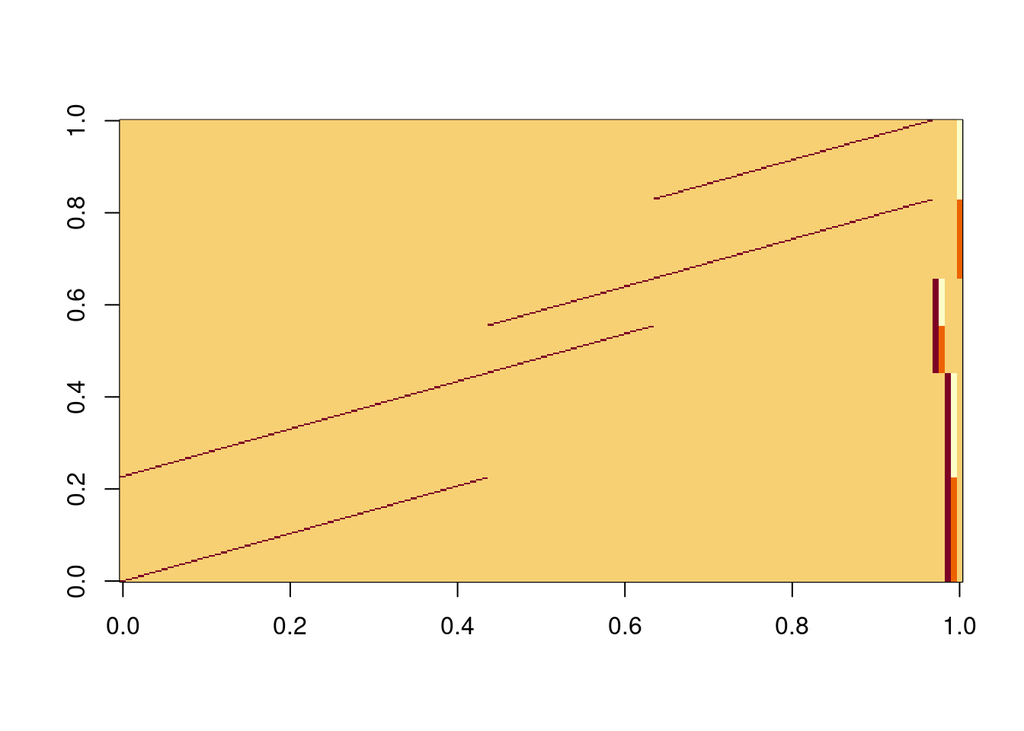

```r
# Get contrast
X_a <- get_contrast_A(dat)
# Full contrast image
image(t(X_a))
```

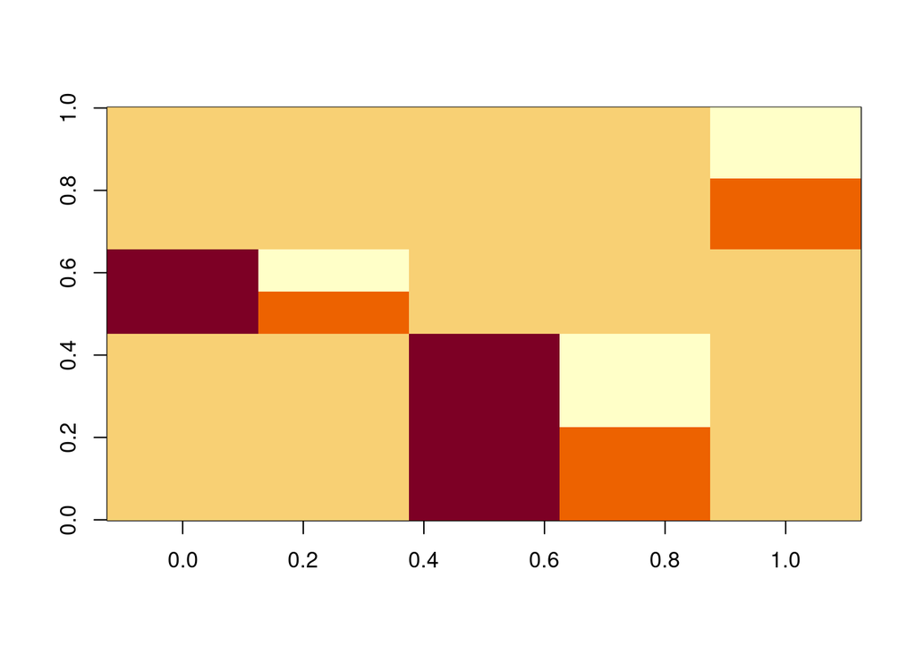

```r
# Only manipulation contrast
make_condition_contrast_image(X_a)
```

#### nWayAov

```r
# Get gMap
gMap <- get_gMap(X_a)
# Run nWayAOV
out <- get_bf_samp(y = dat$value, x = X_a, gMap = gMap, rscale = r,
                   no_iter = no_iter, filter_iter = filter_iter)
# Get simple BF
bf_out_a <- out[[1]]
# Get sampled data
samp_out_a <- out[[2]]
```

##### Check estimated values

```r
checkmeans_a <- with(dat, tapply(value, cond_code, mean))
pm.effest.a <- colMeans(samp_out_a)
```

Contrast A :

- mu: pay-off intercept
- beta 1: muller-lyer intercept
- beta 2: muller-lyer (long-short)
- beta 3: base-rate intercept
- beta 4: base-rate (long-short)
- beta 5: pay-off (long-short)

```r
# get bias manipulation beta names
beta_names <- paste0('beta_', grep('x[0-9]{1}$', colnames(X_a)))

# Rename columns
sampled_means_a <-
  set_names(pm.effest.a[c('mu', beta_names)], c('mu', 'ml_int', 'ml_bd', 'br_int', 'br_bd', 'po_bd'))

# Compare means
checkmeans_a
```

```
##       balo       bash       mulo       mush       palo       pash
##  0.1829330 -0.3585492  0.1487671 -0.2115886  0.1504510 -0.5345864
```

```r
c(
  'balo' = sampled_means_a['mu'] + sampled_means_a['br_int'] + .5 * sampled_means_a['br_bd'],
  'bash' = sampled_means_a['mu'] + sampled_means_a['br_int'] - .5 * sampled_means_a['br_bd'],

  'mulo' = sampled_means_a['mu'] + sampled_means_a['ml_int'] + .5 * sampled_means_a['ml_bd'],
  'mush' = sampled_means_a['mu'] + sampled_means_a['ml_int'] - .5 * sampled_means_a['ml_bd'],

  'palo' = sampled_means_a['mu'] + .5 * sampled_means_a['po_bd'],
  'palo' = sampled_means_a['mu'] - .5 * sampled_means_a['po_bd']
)
```

```
##    balo.mu    bash.mu    mulo.mu    mush.mu    palo.mu    palo.mu
##  0.1711964 -0.3533296  0.1184495 -0.2016696  0.1524430 -0.5114736
```

### Contrast B: all within cond effects are the same size.

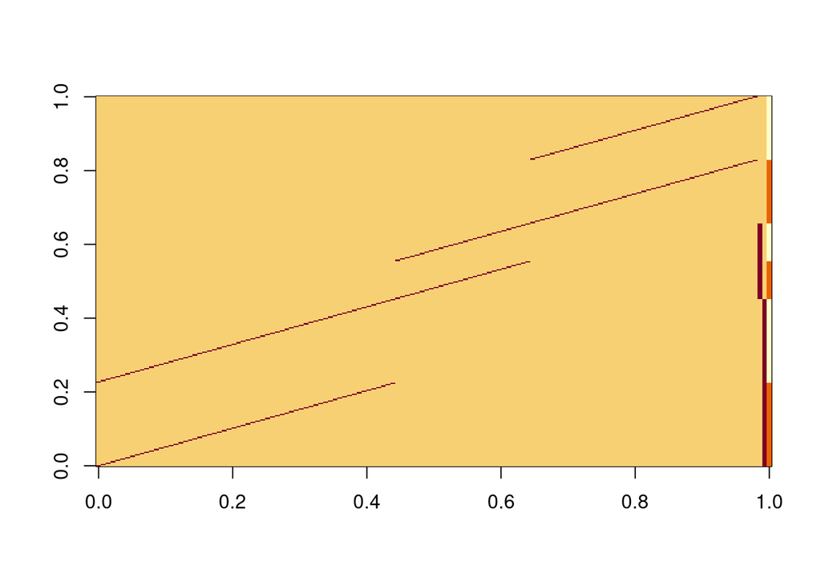

```r
# Get contrast
X_b <- get_contrast_B(dat)
# Full contrast image
image(t(X_b))
```

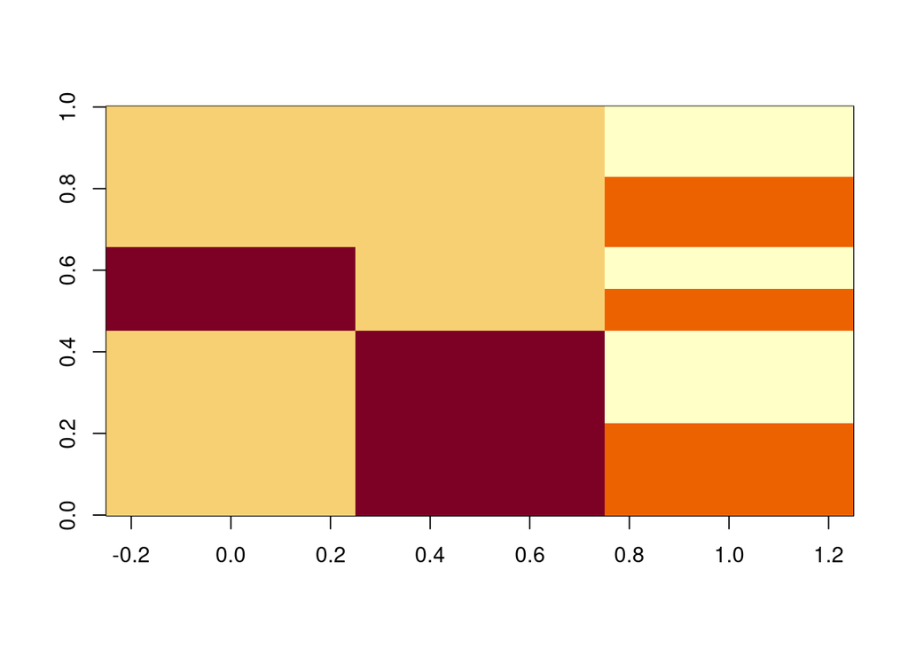

```r
# Only manipulation contrast
make_condition_contrast_image(X_b)
```

#### nWayAov

```r
# Get gMap
gMap <- get_gMap(X_b)
# Run nWayAOV
out <- get_bf_samp(y = dat$value, x = X_b, gMap = gMap, rscale = r,
                   no_iter = no_iter, filter_iter = filter_iter)
# Get simple BF
bf_out_b <- out[[1]]
# Get sampled data
samp_out_b <- out[[2]]
```

##### Check estimated values

```r
checkmeans_b <- with(dat, tapply(value, cond_code, mean))
pm.effest.b <- colMeans(samp_out_b)
```

Contrasts:

- mu: payoff intercept
- beta 1: muller-lyer intercept
- beta 2: base-rate intercept
- beta 3: (mulo,balo,palo) - (mush,bash,pash)

```r
# get bias manipulation beta names
beta_names <- paste0('beta_', grep('x[0-9]{1}$', colnames(X_b)))

# Rename columns
sampled_means_b <-
  set_names(pm.effest.b[c('mu', beta_names)], c('mu', 'ml_int', 'br_int', 'mlbrpo_bd'))

# Compare means
checkmeans_a
```

```
##       balo       bash       mulo       mush       palo       pash
##  0.1829330 -0.3585492  0.1487671 -0.2115886  0.1504510 -0.5345864
```

```r
c(

  'balo' = sampled_means_b['mu'] + sampled_means_b['br_int'] + .5 * sampled_means_b['mlbrpo_bd'],
  'bash' = sampled_means_b['mu'] + sampled_means_b['br_int'] - .5 * sampled_means_b['mlbrpo_bd'],

  'mulo' = sampled_means_b['mu'] + sampled_means_b['ml_int'] + .5 * sampled_means_b['mlbrpo_bd'],
  'mush' = sampled_means_b['mu'] + sampled_means_b['ml_int'] - .5 * sampled_means_b['mlbrpo_bd'],

  'palo' = sampled_means_b['mu']  + .5 * sampled_means_b['mlbrpo_bd'],
  'palo' = sampled_means_b['mu']  - .5 * sampled_means_b['mlbrpo_bd']

)
```

```
##     balo.mu     bash.mu     mulo.mu     mush.mu     palo.mu     palo.mu
##  0.18130435 -0.36568249  0.23009096 -0.31689588  0.09177458 -0.45521226
```

### Contrast C: Bias direction effect is equal in Muller-Lyer and Baserate, different in Payoff [(ML == BR) != PO]

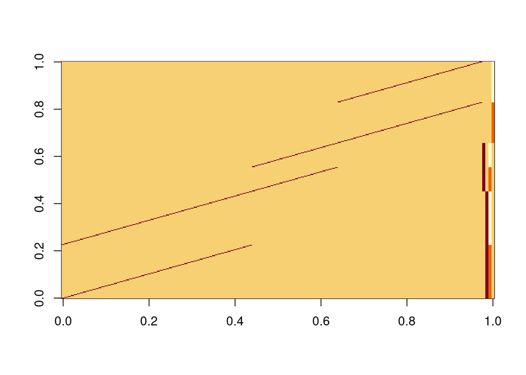

```r
# Get contrast
X_c <- get_contrast_C(dat)
# Full contrast image
image(t(X_c))
```

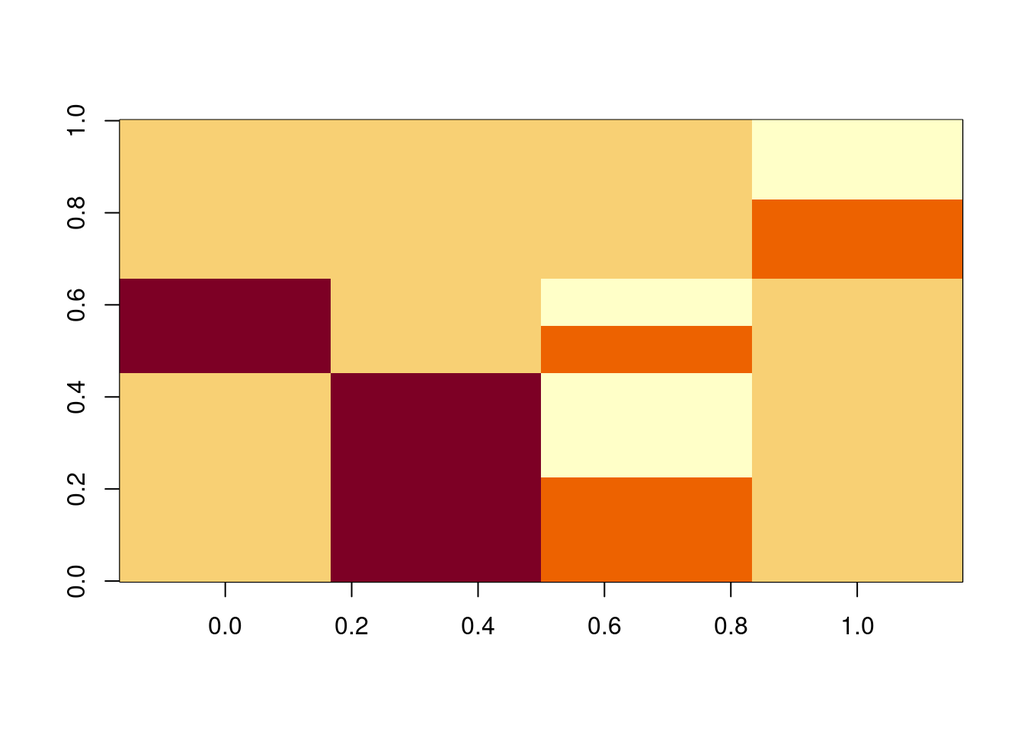

```r
# Only manipulation contrast
make_condition_contrast_image(X_c)
```

#### nWayAov

```r
# Get gMap
gMap <- get_gMap(X_c)
# Run nWayAOV
out <- get_bf_samp(y = dat$value, x = X_c, gMap = gMap, rscale = r,
                   no_iter = no_iter, filter_iter = filter_iter)
# Get simple BF
bf_out_c <- out[[1]]
# Get sampled data
samp_out_c <- out[[2]]
```

##### Check estimated values

```r
checkmeans_c <- checkmeans_a
pm.effest.c <- colMeans(samp_out_c)
```

Contrasts:

- mu: payoff intercept
- beta 1: muller-lyer intercept
- beta 2: base-rate intercept
- beta 3: (mulo, balo) - (mush, bash)
- beta 4: payoff (long-short)

```r
# get bias manipulation beta names
beta_names <- paste0('beta_', grep('x[0-9]{1}$', colnames(X_c)))
# Rename columns
sampled_means_c <-
  set_names(pm.effest.c[c('mu', beta_names)], c('mu', 'ml_int', 'br_int', 'mlbr_bd', 'po_bd'))

# Compare means
checkmeans_c
```

```
##       balo       bash       mulo       mush       palo       pash
##  0.1829330 -0.3585492  0.1487671 -0.2115886  0.1504510 -0.5345864
```

```r
c(

  'balo' = sampled_means_c['mu'] +  sampled_means_c['br_int'] + .5 * sampled_means_c['mlbr_bd'],
  'bash' = sampled_means_c['mu'] +  sampled_means_c['br_int'] - .5 * sampled_means_c['mlbr_bd'],

  'mulo' = sampled_means_c['mu'] + sampled_means_c['ml_int']  + .5 * sampled_means_c['mlbr_bd'],
  'mush' = sampled_means_c['mu'] + sampled_means_c['ml_int']  - .5 * sampled_means_c['mlbr_bd'],

  'palo' = sampled_means_c['mu'] + .5 * sampled_means_c['po_bd'],
  'palo' = sampled_means_c['mu'] - .5 * sampled_means_c['po_bd']

)
```

```
##    balo.mu    bash.mu    mulo.mu    mush.mu    palo.mu    palo.mu
##  0.1444956 -0.3274245  0.1926520 -0.2792681  0.1495973 -0.5130327
```

### Contrast D: Bias direction effect is equal in Muller-Lyer and Payoff, different in Base rate [(ML == PO) != BR]

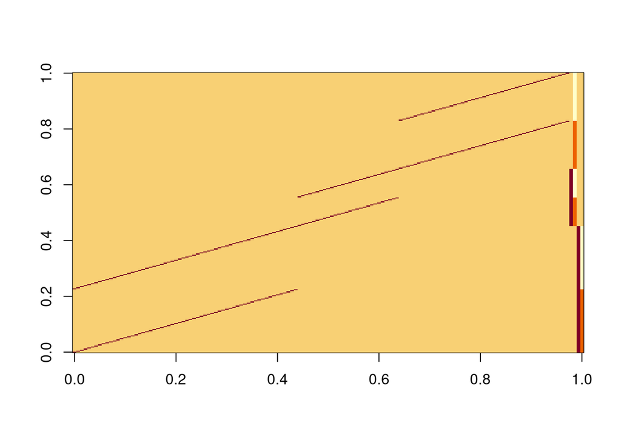

```r
# Get contrast
X_d <- get_contrast_D(dat)
# Full contrast image
image(t(X_d))
```

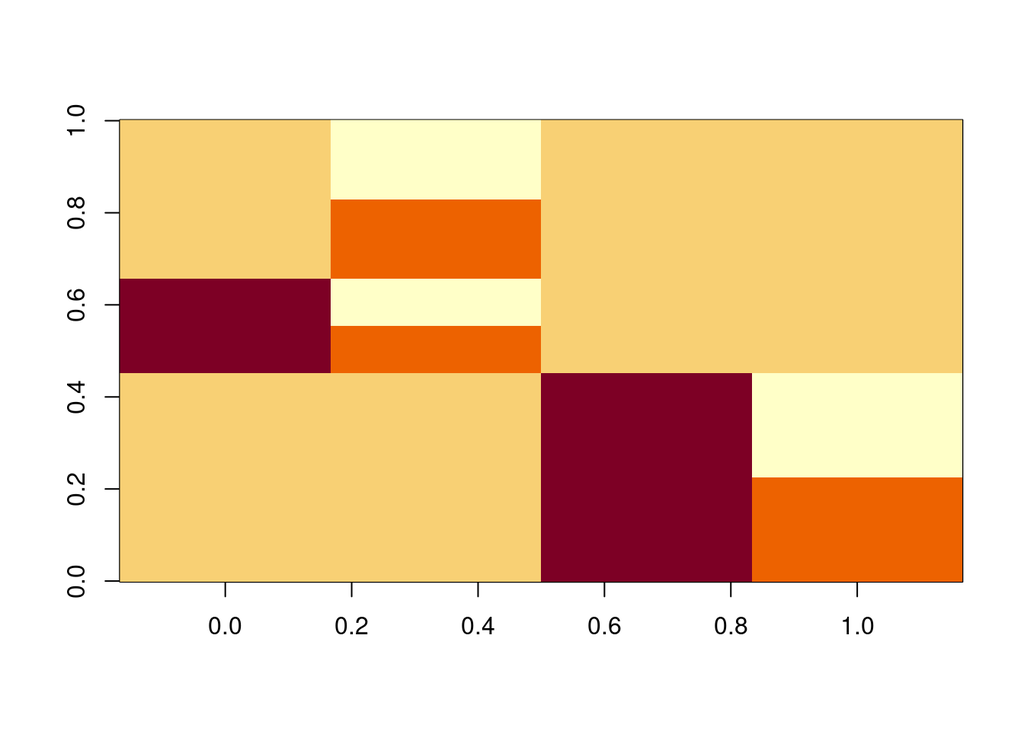

```r
# Only manipulation contrast
make_condition_contrast_image(X_d)
```

#### nWayAov

```r
# Get gMap
gMap <- get_gMap(X_d)
# Run nWayAOV
out <- get_bf_samp(y = dat$value, x = X_d, gMap = gMap, rscale = r,
                   no_iter = no_iter, filter_iter = filter_iter)
# Get simple BF
bf_out_d <- out[[1]]
# Get sampled data
samp_out_d <- out[[2]]
```

##### Check estimated values

```r
checkmeans_d <- checkmeans_a
pm.effest.d <- colMeans(samp_out_d)
```

Contrasts:

- mu: payoff intercept
- beta 1: muller-lyer intercept
- beta 2: (mulo, palo) - (mush, pash)
- beta 3: base-rate intercept
- beta 4: base-rate (long-short)

```r
# get bias manipulation beta names
beta_names <- paste0('beta_', grep('x[0-9]{1}$', colnames(X_d)))

# Rename columns
sampled_means_d <-
  set_names(pm.effest.d[c('mu', beta_names)], c('mu', 'ml_int', 'mlpo_bd', 'br_int', 'br_bd'))

# Compare means
checkmeans_d
```

```
##       balo       bash       mulo       mush       palo       pash
##  0.1829330 -0.3585492  0.1487671 -0.2115886  0.1504510 -0.5345864
```

```r
c(

  'balo' = sampled_means_d['mu'] + sampled_means_d['br_int'] + .5 * sampled_means_d['br_bd'],
  'bash' = sampled_means_d['mu'] + sampled_means_d['br_int'] - .5 * sampled_means_d['br_bd'],

  'mulo' = sampled_means_d['mu'] + sampled_means_d['ml_int'] + .5 * sampled_means_d['mlpo_bd'],
  'mush' = sampled_means_d['mu'] + sampled_means_d['ml_int'] - .5 * sampled_means_d['mlpo_bd'],

  'palo' = sampled_means_d['mu']  + .5 * sampled_means_d['mlpo_bd'],
  'palo' = sampled_means_d['mu']  - .5 * sampled_means_d['mlpo_bd']

)
```

```
##     balo.mu     bash.mu     mulo.mu     mush.mu     palo.mu     palo.mu
##  0.16822537 -0.35289169  0.23328957 -0.31565354  0.09391404 -0.45502907
```

### Contrast E: Bias direction effect in the Muller-Lyer condition, no effect in base rate and payoff [(mulo > mush) & (balo == bash) & (palo = pash)]

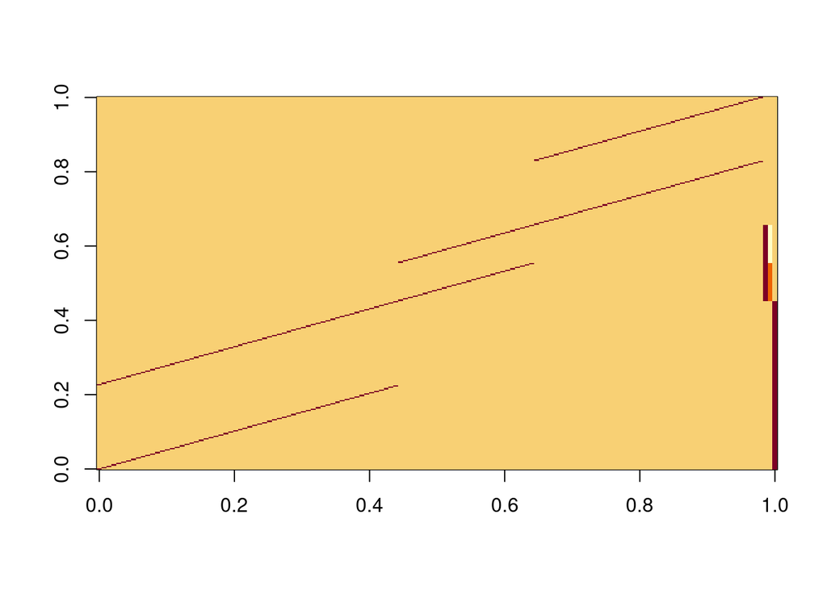

```r
# Get contrast
X_e <- get_contrast_E(dat)
# Full contrast image
image(t(X_e))
```

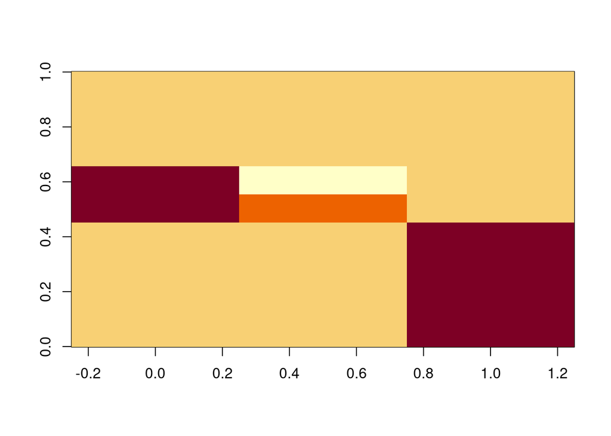

```r
# Only manipulation contrast
make_condition_contrast_image(X_e)
```

#### nWayAov

```r
# Get gMap
gMap <- get_gMap(X_e)
# Run nWayAOV
out <- get_bf_samp(y = dat$value, x = X_e, gMap = gMap, rscale = r,
                   no_iter = no_iter, filter_iter = filter_iter)
# Get simple BF
bf_out_e <- out[[1]]
# Get sampled data
samp_out_e <- out[[2]]
```

#### Check estimated values

```r
pm.effest.e <- colMeans(samp_out_e)
```

Contrasts:

- mu: payoff intercept
- beta 1: muller-lyer intercept
- beta 2: muller-lyer (long-short)
- beta 3: base-rate intercept

```r
# get bias manipulation beta names
beta_names <- paste0('beta_', grep('x[0-9]{1}$', colnames(X_e)))

# Rename columns
sampled_means_e <-
  set_names(pm.effest.e[c('mu', beta_names)], c('mu', 'ml_int', 'ml_bd', 'br_int'))
c(
  'ba' = mean(checkmeans_a['balo'], checkmeans_a['bash']),
  'pa' =mean(checkmeans_a['palo'], checkmeans_a['pash']),
  checkmeans_a[c('mulo', 'mush')]
)
```

```
##         ba         pa       mulo       mush
##  0.1829330  0.1504510  0.1487671 -0.2115886
```

```r
c(

  'ba' = sampled_means_e['mu'] + sampled_means_e['br_int'],
  'pa' = sampled_means_e['mu'],

  'mulo' = sampled_means_e['mu'] + sampled_means_e['ml_int'] + .5 * sampled_means_e['ml_bd'],
  'mush' = sampled_means_e['mu'] + sampled_means_e['ml_int'] - .5 * sampled_means_e['ml_bd']


)
```

```
##       ba.mu       pa.mu     mulo.mu     mush.mu
## -0.09114032 -0.18186673  0.11440026 -0.19844224
```

### Contrast F: No effect in any bias source [(mulo = mush) != (balo == bash) != (palo = pash)]

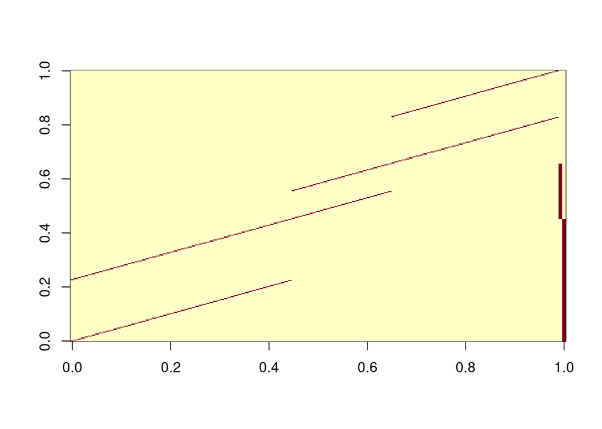

```r
# Get contrast
X_f <- get_contrast_F(dat)
# Full contrast image
image(t(X_f))
```

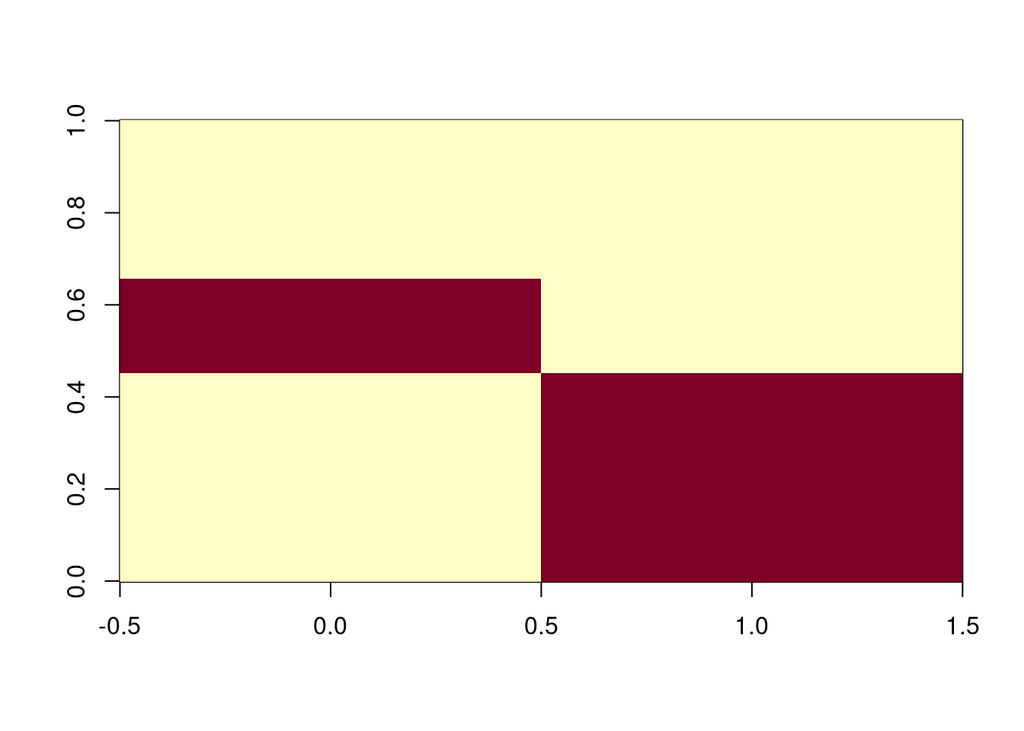

```r
# Only manipulation contrast
make_condition_contrast_image(X_f)
```

#### nWayAov

```r
# Get gMap
gMap <- get_gMap(X_f)
# Run nWayAOV
out <- get_bf_samp(y = dat$value, x = X_f, gMap = gMap, rscale = r,
                   no_iter = no_iter, filter_iter = filter_iter)
# Get simple BF
bf_out_f <- out[[1]]
# Get sampled data
samp_out_f <- out[[2]]
```

#### Check estimated values

Contrasts:

- mu: payoff intercept
- beta 1: muller-lyer intercept
- beta 2: base-rate intercept

```r
checkmeans_f <- with(dat, tapply(value, bias_source, mean))
pm.effest.f <- colMeans(samp_out_f)
```

```r
# get bias manipulation beta names
beta_names <- paste0('beta_', grep('x[0-9]{1}$', colnames(X_f)))

# Rename columns
sampled_means_f <-
  set_names(pm.effest.f[c('mu', beta_names)], c('mu', 'ml_int', 'br_int'))


# Compare means
checkmeans_f
```

```
##    baserate  mullerlyer      payoff
## -0.08780805 -0.03141075 -0.19206769
```

```r
c(
  'ba' = sampled_means_f['mu'] + sampled_means_f['br_int'],
  'ml' = sampled_means_f['mu'] + sampled_means_f['ml_int'],
  'pa' = sampled_means_f['mu']
)
```

```
##       ba.mu       ml.mu       pa.mu
## -0.09057149 -0.04099366 -0.18136359
```

### Contrast G: Bias direction effect in base rate and Muller-Lyer, no effect in payoff [(mulo > mush) > (balo > bash) & (palo = pash)]

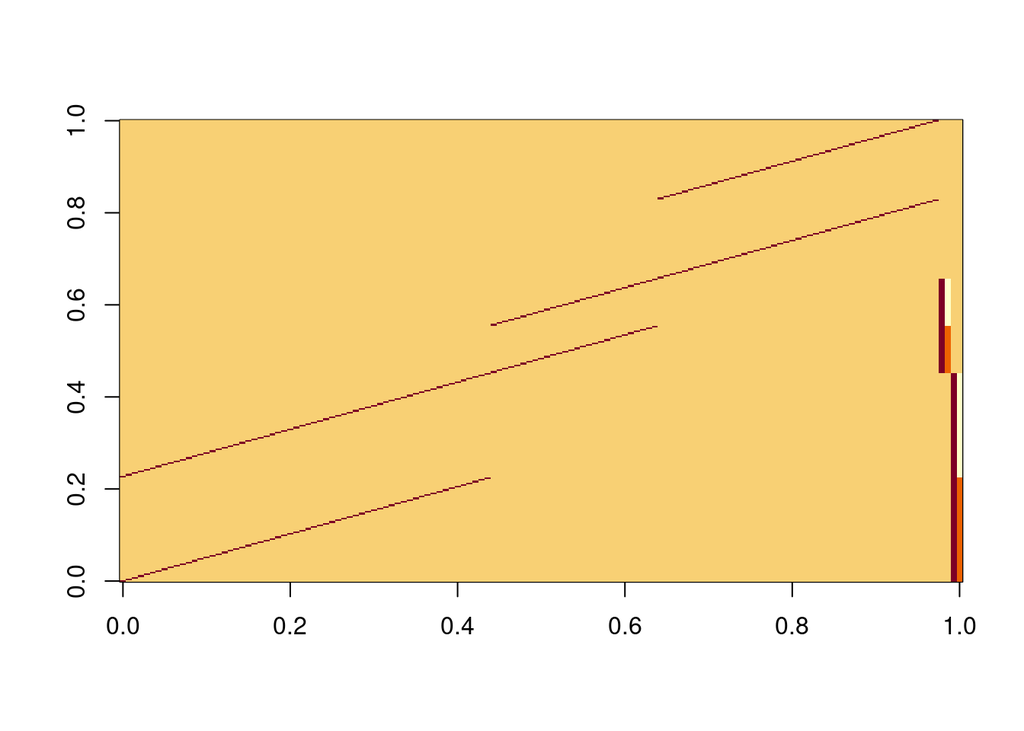

```r
# Get contrast
X_g <- get_contrast_G(dat)
# Full contrast image
image(t(X_g))
```

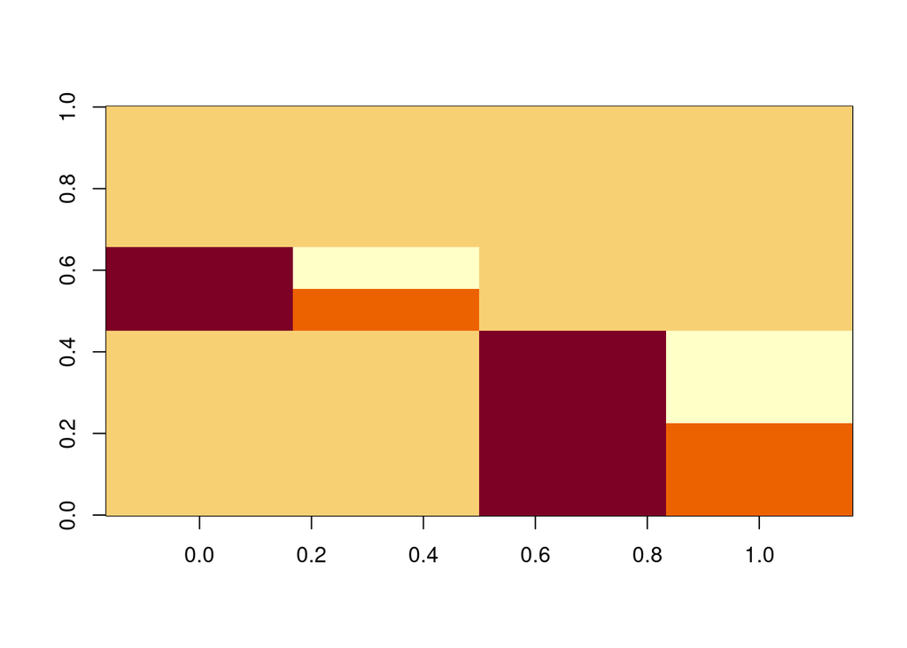

```r
# Only manipulation contrast
make_condition_contrast_image(X_g)
```

#### nWayAov

```r
# Get gMap
gMap <- get_gMap(X_g)
# Run nWayAOV
out <- get_bf_samp(y = dat$value, x = X_g, gMap = gMap, rscale = r,
                   no_iter = no_iter, filter_iter = filter_iter)
# Get simple BF
bf_out_g <- out[[1]]
# Get sampled data
samp_out_g <- out[[2]]
```

#### Check estimated values

```r
pm.effest.g <- colMeans(samp_out_g)
```

Contrasts:

- mu: payoff intercept
- beta 1: muller-lyer intercept
- beta 2: muller-lyer (long-short)
- beta 3: base-rate intercept
- beta 4: base-rate (long-short)

```r
# get bias manipulation beta names
beta_names <- paste0('beta_', grep('x[0-9]{1}$', colnames(X_g)))

# Rename columns
sampled_means_g <-
  set_names(pm.effest.g[c('mu', beta_names)], c('mu', 'ml_int', 'ml_bd', 'br_int', 'br_bd'))
```

```r
c(
  checkmeans_a['balo'],
  checkmeans_a['bash'],
  checkmeans_a[c('mulo', 'mush')],
  'pa'=mean(checkmeans_a['palo'], checkmeans_a['pash'])
)
```

```
##       balo       bash       mulo       mush         pa
##  0.1829330 -0.3585492  0.1487671 -0.2115886  0.1504510
```

```r
c(
  'balo' = sampled_means_g['mu'] + sampled_means_g['br_int'] + .5 * sampled_means_g['br_bd'],
  'bash' = sampled_means_g['mu'] + sampled_means_g['br_int'] - .5 * sampled_means_g['br_bd'],

  'mulo' = sampled_means_g['mu'] + sampled_means_g['ml_int'] + .5 * sampled_means_g['ml_bd'],
  'mulo' = sampled_means_g['mu'] + sampled_means_g['ml_int'] - .5 * sampled_means_g['ml_bd'],

  'pa' = sampled_means_g['mu']
)
```

```
##    balo.mu    bash.mu    mulo.mu    mulo.mu      pa.mu
##  0.1691315 -0.3496664  0.1162468 -0.1987331 -0.1816727
```

### Contrast H: Bias direction effect in Payoff and Muller-Lyer, no effect in base rate [(mulo > mush) > (palo > pash) & (balo = bash)]

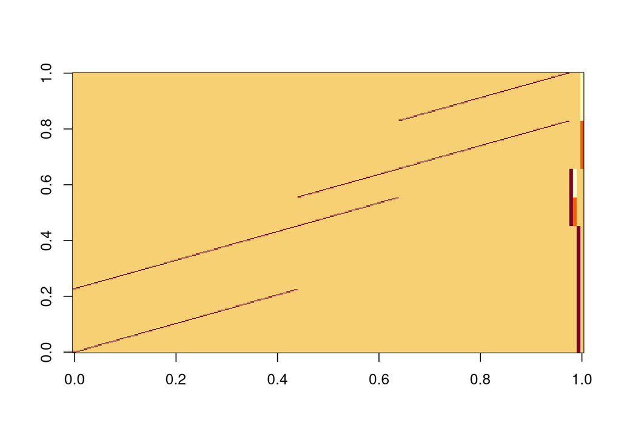

```r
# Get contrast
X_h <- get_contrast_H(dat)
# Full contrast image
image(t(X_h))
```

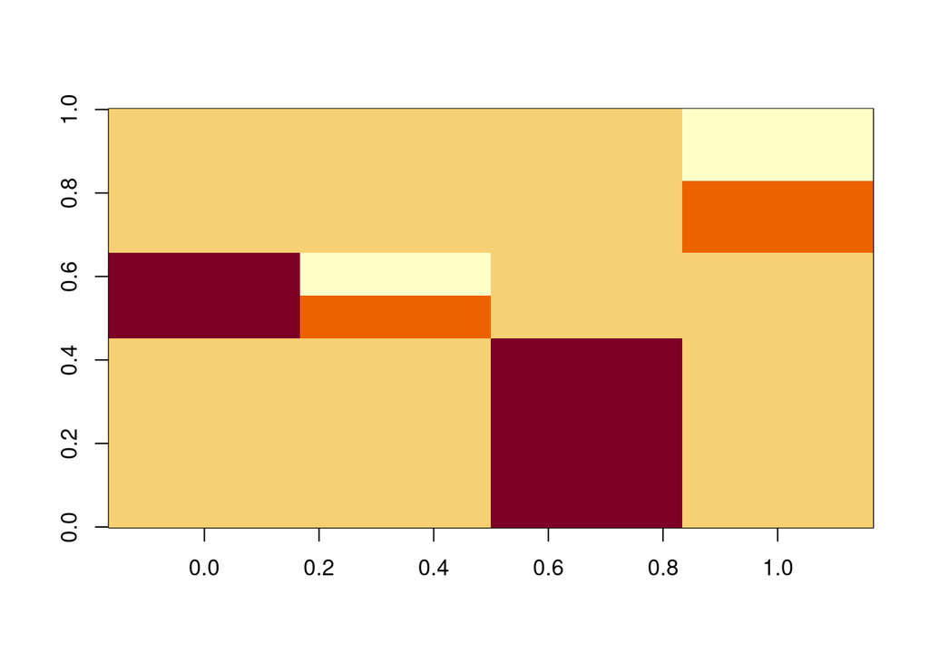

```r
# Only manipulation contrast
make_condition_contrast_image(X_h)
```

#### nWayAov

```r
# Get gMap
gMap <- get_gMap(X_h)
# Run nWayAOV
out <- get_bf_samp(y = dat$value, x = X_h, gMap = gMap, rscale = r,
                   no_iter = no_iter, filter_iter = filter_iter)
# Get simple BF
bf_out_h <- out[[1]]
# Get sampled data
samp_out_h <- out[[2]]
```

#### Check estimated values

```r
pm.effest.h <- colMeans(samp_out_h)
```

Contrasts:

```r
# get bias manipulation beta names
beta_names <- paste0('beta_', grep('x[0-9]{1}$', colnames(X_h)))

# Rename columns
sampled_means_h <-
  set_names(pm.effest.h[c('mu', beta_names)], c('mu', 'ml_int', 'ml_bd', 'br_int', 'po_bd'))
```

```r
c(
  checkmeans_a['palo'],
  checkmeans_a['pash'],
  checkmeans_a[c('mulo', 'mush')],
  'ba' = mean(checkmeans_a['balo'], checkmeans_a['bash'])
)
```

```
##       palo       pash       mulo       mush         ba
##  0.1504510 -0.5345864  0.1487671 -0.2115886  0.1829330
```

```r
c(

  'palo' = sampled_means_h['mu']  + .5 * sampled_means_h['po_bd'],
  'pash' = sampled_means_h['mu'] - .5 * sampled_means_h['po_bd'],

  'mulo' = sampled_means_h['mu'] + sampled_means_h['ml_int'] + .5 * sampled_means_h['ml_bd'],
  'mush' = sampled_means_h['mu'] + sampled_means_h['ml_int'] - .5 * sampled_means_h['ml_bd'],

  'ba' = sampled_means_h['mu']

)
```

```
##    palo.mu    pash.mu    mulo.mu    mush.mu      ba.mu
##  0.1465252 -0.5113564  0.1181141 -0.1989082 -0.1824156
```

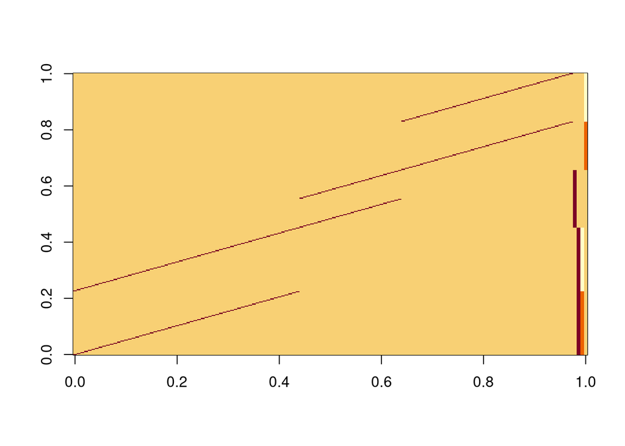

```r
# Get contrast
X_i <- get_contrast_I(dat)
# Full contrast image
image(t(X_i))
```

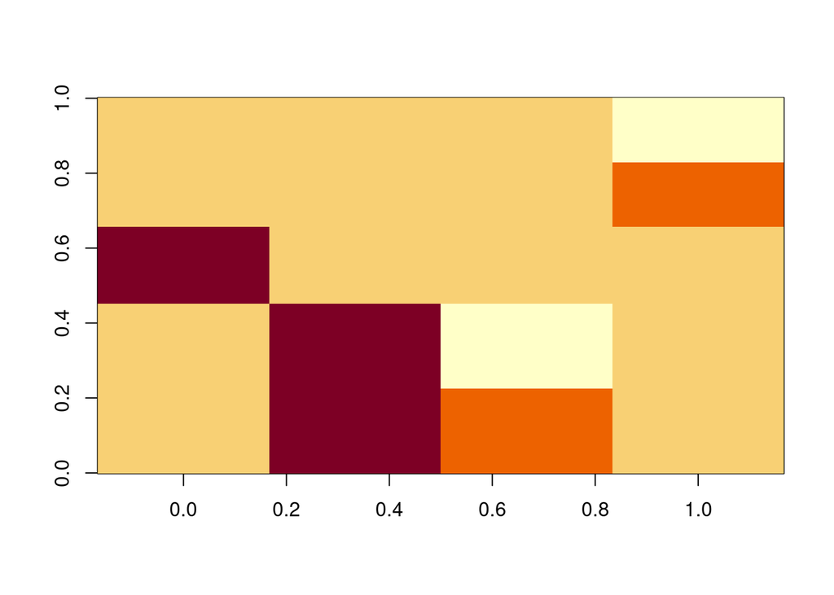

```r
# Only manipulation contrast
make_condition_contrast_image(X_i)
```

#### nWayAov

```r
# Get gMap
gMap <- get_gMap(X_i)
# Run nWayAOV
out <- get_bf_samp(y = dat$value, x = X_i, gMap = gMap, rscale = r,
                   no_iter = no_iter, filter_iter = filter_iter)
# Get simple BF
bf_out_i <- out[[1]]
# Get sampled data
samp_out_i <- out[[2]]
```

#### Check estimated values

```r
pm.effest.i <- colMeans(samp_out_i)
```

Contrasts:

- mu: payoff intercept
- beta 1: muller-lyer intercept
- beta 2: base-rate intercept
- beta 3: base-rate (long-short)
- beta 4: payoff (long-short)

```r
# get bias manipulation beta names
beta_names <- paste0('beta_', grep('x[0-9]{1}$', colnames(X_i)))

# Rename columns
sampled_means_i <-
  set_names(pm.effest.i[c('mu', beta_names)], c('mu', 'ml_int', 'br_int', 'br_bd', 'po_bd'))
```

```r
c(mu = mean(checkmeans_a[c('mulo', 'mush')]), checkmeans_a[c('palo', 'pash', 'balo', 'bash')])
```

```
##          mu        palo        pash        balo        bash
## -0.03141075  0.15045101 -0.53458639  0.18293304 -0.35854915
```

```r
c(
  'mulo' = sampled_means_i['mu'] + sampled_means_i['ml_int'],

  'palo' = sampled_means_i['mu']  + .5 * sampled_means_i['po_bd'],
  'pash' = sampled_means_i['mu'] - .5 * sampled_means_i['po_bd'],

  'balo' = sampled_means_i['mu'] + sampled_means_i['br_int'] + .5 * sampled_means_i['br_bd'],
  'bash' = sampled_means_i['mu'] + sampled_means_i['br_int'] - .5 * sampled_means_i['br_bd']

)
```

```
##     mulo.mu     palo.mu     pash.mu     balo.mu     bash.mu
## -0.04121343  0.15038211 -0.51217666  0.17239410 -0.35099009
```

### Contrast J: Bias direction effect in the payoff condition, no effect in base rate and muller lyer [(palo > pash) & (balo == bash) & (mulo = mush)]

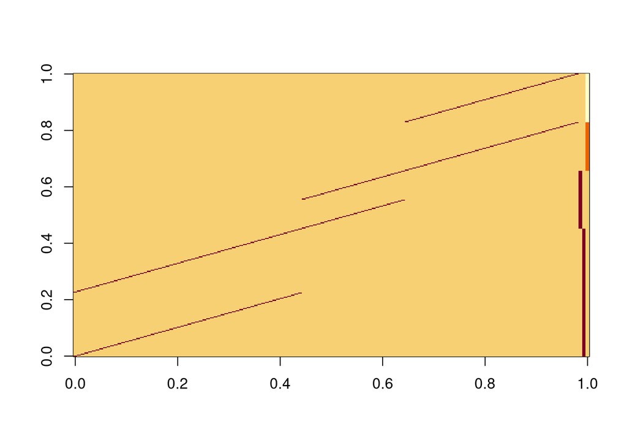

```r
# Get contrast
X_j <- get_contrast_J(dat)
# Full contrast image
image(t(X_j))
```

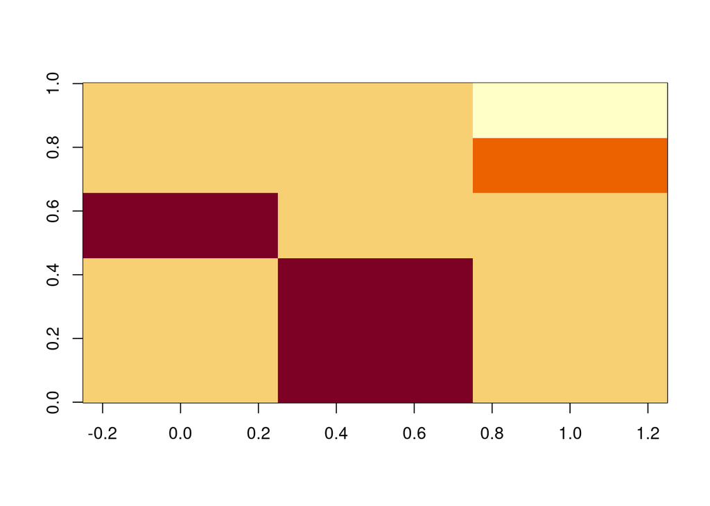

```r
# Only manipulation contrast
make_condition_contrast_image(X_j)
```

#### nWayAov

```r
# Get gMap
gMap <- get_gMap(X_j)
# Run nWayAOV
out <- get_bf_samp(y = dat$value, x = X_j, gMap = gMap, rscale = r,
                   no_iter = no_iter, filter_iter = filter_iter)
# Get simple BF
bf_out_j <- out[[1]]
# Get sampled data
samp_out_j <- out[[2]]
```

#### Check estimated values

```r
pm.effest.j <- colMeans(samp_out_j)
```

Contrasts:

- mu: payoff intercept
- beta 1: muller-lyer intercept
- beta 2: base-rate intercept
- beta 3: payoff (long-short)

```r
# get bias manipulation beta names
beta_names <- paste0('beta_', grep('x[0-9]{1}$', colnames(X_j)))

# Rename columns
sampled_means_j <-
  set_names(pm.effest.j[c('mu', beta_names)], c('mu', 'ml_int', 'br_int', 'pa_bd'))
```

```r
c(
  'ba' = mean(checkmeans_a['balo'], checkmeans_a['bash']),
  'mu' = mean(checkmeans_a[c('mulo', 'mush')]),
  checkmeans_a['palo'],
  checkmeans_a['pash']
)
```

```
##          ba          mu        palo        pash
##  0.18293304 -0.03141075  0.15045101 -0.53458639
```

```r
c(

  'ba' = sampled_means_j['mu'] + sampled_means_j['br_int'],
  'mu' = sampled_means_j['mu'] + sampled_means_j['ml_int'],

  'palo' = sampled_means_j['mu'] + .5 * sampled_means_j['pa_bd'],
  'pash' = sampled_means_j['mu'] - .5 * sampled_means_j['pa_bd']


)
```

```
##       ba.mu       mu.mu     palo.mu     pash.mu
## -0.09001473 -0.04070626  0.14894934 -0.51301999
```

### Contrast K: Bias direction effect in the base-rate condition, no effect in payoff and muller lyer [(balo > bash) & (palo == pash) & (mulo = mush)]

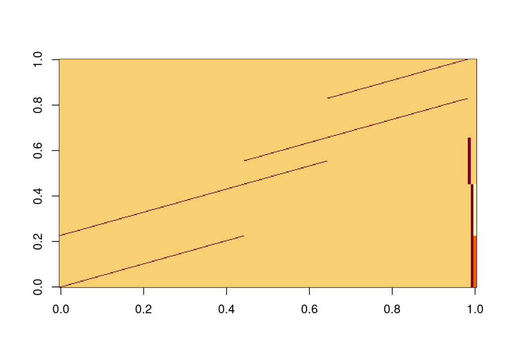

```r
# Get contrast
X_k <- get_contrast_K(dat)
# Full contrast image
image(t(X_k))
```

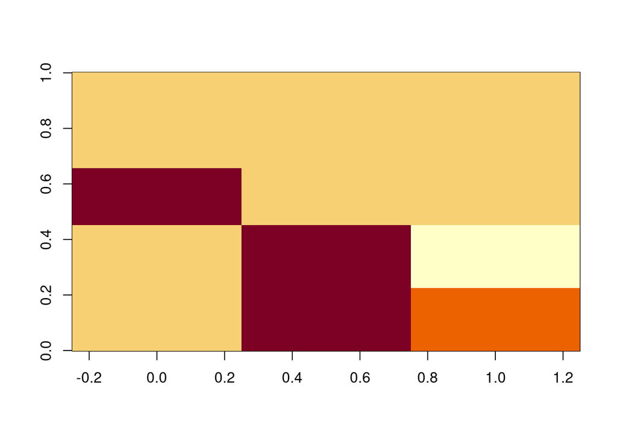

```r
# Only manipulation contrast
make_condition_contrast_image(X_k)
```

#### nWayAov

```r
# Get gMap
gMap <- get_gMap(X_k)
# Run nWayAOV
out <- get_bf_samp(y = dat$value, x = X_k, gMap = gMap, rscale = r,
                   no_iter = no_iter, filter_iter = filter_iter)
# Get simple BF
bf_out_k <- out[[1]]
# Get sampled data
samp_out_k <- out[[2]]
```

#### Check estimated values

```r
pm.effest.k <- colMeans(samp_out_k)
```

Contrasts:

```r
# get bias manipulation beta names
beta_names <- paste0('beta_', grep('x[0-9]{1}$', colnames(X_k)))

# Rename columns
sampled_means_k <-
  set_names(pm.effest.k[c('mu', beta_names)], c('mu', 'ml_int', 'br_int', 'ba_bd'))

c(
  'balo' = checkmeans_a['balo'],
  'bash' = checkmeans_a['bash'],
  'mu' = mean(checkmeans_a[c('mulo', 'mush')]),
  'pa' = mean(checkmeans_a['palo'], checkmeans_a['pash'])
)
```

```
##   balo.balo   bash.bash          mu          pa
##  0.18293304 -0.35854915 -0.03141075  0.15045101
```

```r
c(

  'balo' = sampled_means_k['mu'] + sampled_means_k['br_int'] + .5 * sampled_means_k['ba_bd'],
  'bash' = sampled_means_k['mu'] + sampled_means_k['br_int'] - .5 * sampled_means_k['ba_bd'],
  'mu' = sampled_means_k['mu'] + sampled_means_k['ml_int'],
  'palo' = sampled_means_k['mu']

)
```

```
##     balo.mu     bash.mu       mu.mu     palo.mu
##  0.16968655 -0.35054213 -0.04146547 -0.18211869
```

### Contrast L: Bias direction effect is equal in Base rate and Payoff, different in Muller-Lyer [(BR == PO) != ML]

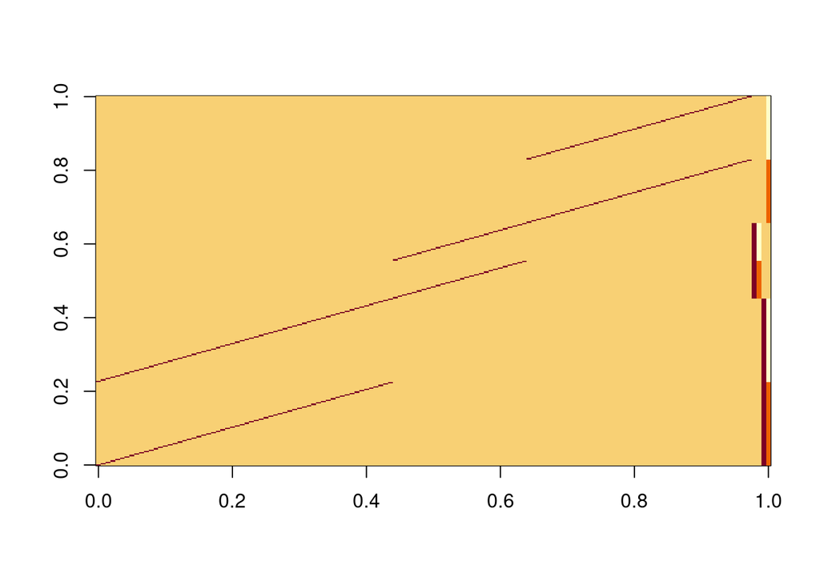

```r
# Get contrast
X_l <- get_contrast_L(dat)
# Full contrast image
image(t(X_l))
```

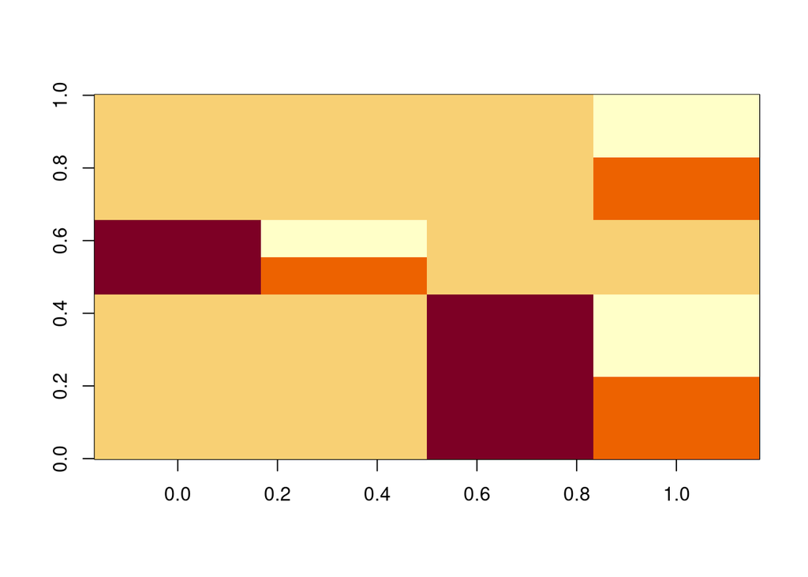

```r
# Only manipulation contrast
make_condition_contrast_image(X_l)
```

#### nWayAov

```r
# Get gMap
gMap <- get_gMap(X_l)
# Run nWayAOV
out <- get_bf_samp(y = dat$value, x = X_l, gMap = gMap, rscale = r,
                   no_iter = no_iter, filter_iter = filter_iter)
# Get simple BF
bf_out_l <- out[[1]]
# Get sampled data
samp_out_l <- out[[2]]
```

##### Check estimated values

```r
checkmeans_l <- checkmeans_a
pm.effest.l <- colMeans(samp_out_l)
```

Contrasts:

- mu: payoff intercept
- beta 1: muller-lyer intercept
- beta 2: muller-lyer (long-short)
- beta 3: base-rate intercept
- beta 4: (balo, palo) - (bash, pash)

```r
# get bias manipulation beta names
beta_names <- paste0('beta_', grep('x[0-9]{1}$', colnames(X_l)))

# Rename columns
sampled_means_l <-
  set_names(pm.effest.l[c('mu', beta_names)], c('mu', 'ml_int', 'ml_bd', 'br_int', 'brpo_bd'))

# Compare means
checkmeans_l
```

```
##       balo       bash       mulo       mush       palo       pash
##  0.1829330 -0.3585492  0.1487671 -0.2115886  0.1504510 -0.5345864
```

```r
c(

  'balo' = sampled_means_l['mu'] + sampled_means_l['br_int'] + .5 * sampled_means_l['brpo_bd'],
  'bash' = sampled_means_l['mu'] + sampled_means_l['br_int'] - .5 * sampled_means_l['brpo_bd'],

  'mulo' = sampled_means_l['mu'] + sampled_means_l['ml_int'] + .5 * sampled_means_l['ml_bd'],
  'mush' = sampled_means_l['mu'] + sampled_means_l['ml_int'] - .5 * sampled_means_l['ml_bd'],

  'palo' = sampled_means_l['mu']  + .5 * sampled_means_l['brpo_bd'],
  'palo' = sampled_means_l['mu']  - .5 * sampled_means_l['brpo_bd']

)
```

```
##    balo.mu    bash.mu    mulo.mu    mush.mu    palo.mu    palo.mu
##  0.2061089 -0.3873681  0.1186963 -0.2029976  0.1142839 -0.4791931
```

## Priors

```r
# Parameters for prior sampling
R <- 1000000
mu.theta.sd <- 1
# Prior sample
ml <- rnorm(R, 0, mu.theta.sd)
br <- rnorm(R, 0, mu.theta.sd)
po <- rnorm(R, 0, mu.theta.sd)
```

## Posteriors

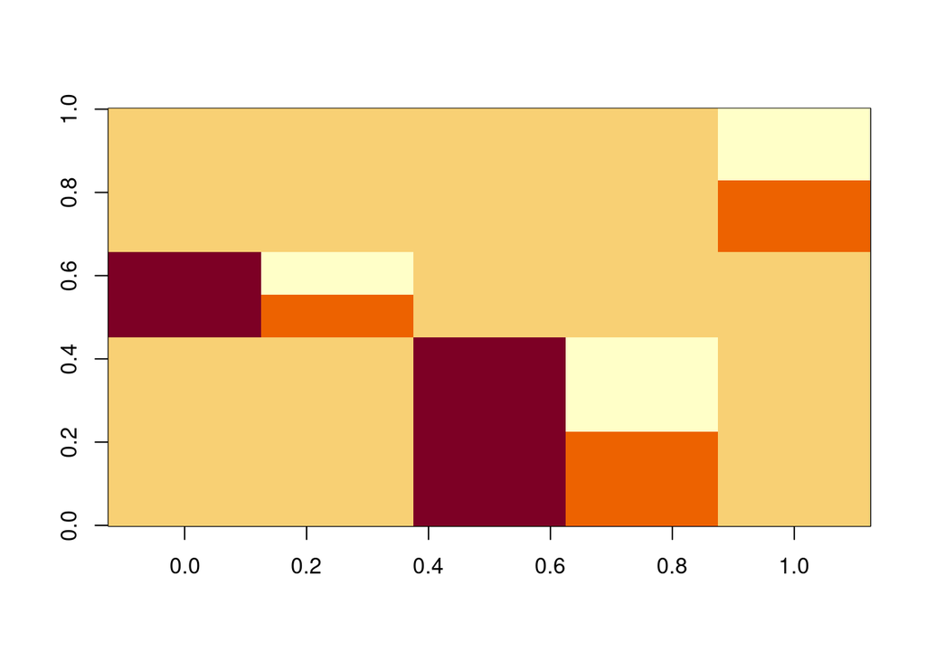

```r
# Number of participant contrast columns
add_to_beta_index <- ncol(id_contrast)

### CONTRAST A -----------------------------------------------------------------

make_condition_contrast_image(X_a)
```

```r
# These refer to the columns where the bias direction effect is
ml_bd <- paste0('beta_', 2 + add_to_beta_index)
br_bd <- paste0('beta_', 4 + add_to_beta_index)
po_bd <- paste0('beta_', 5 + add_to_beta_index)

# 3 bias direction effect sizes, one for each bias source
ba_bigger_ml <- samp_out_a[, br_bd] > samp_out_a[, ml_bd]
pa_bigger_ml <- samp_out_a[, po_bd] > samp_out_a[, ml_bd]
pa_bigger_ba <- samp_out_a[, po_bd] > samp_out_a[, br_bd]

# Priors H-I --------------------------------------------------------
prior_prob_HH <- mean(br > ml & ml < po & br < po)
prior_prob_II <- mean(br > ml & ml < po & br > po)

# Model HH (BR > ML < PO) & PO > BR
post_prob_conHH <-
  mean(
    ba_bigger_ml & pa_bigger_ml & pa_bigger_ba
  )
# Model II (BR > ML < PO) & PO < BR
post_prob_conII <-
  mean(
    ba_bigger_ml & pa_bigger_ml & !pa_bigger_ba
  )

# Priors J-K -------------------------------------------------------

# Models based on model B
prior_prob_JJ <- mean(br < ml & ml > po & br < po)
prior_prob_KK <- mean(br < ml & ml > po & br > po)

# Model MM (BR > ML < PO) & PO > BR
post_prob_conJJ <-
  mean(
    !ba_bigger_ml & !pa_bigger_ml & pa_bigger_ba
  )
# Model NN (BR > ML < PO) & PO < BR
post_prob_conKK <-
  mean(
    !ba_bigger_ml & !pa_bigger_ml & !pa_bigger_ba
  )

# Priors L ---------------------------------------------------

# Models based on model C
prior_prob_LL <- mean(br < ml & ml < po & br < po)
# prior_prob_MM <- mean(br < ml & ml < po & br > po) This constraint is not possible.

# Model OO (BR > ML < PO) & PO > BR
post_prob_conLL <-
  mean(
    !ba_bigger_ml & pa_bigger_ml & pa_bigger_ba
  )

# # Model PP (BR > ML < PO) & PO < BR -> THIS MODEL IS NOT POSSIBLE
# post_prob_conMM <-
#   mean(
#     !ba_bigger_ml & pa_bigger_ml & !pa_bigger_ba
#   )

# Priors M --------------------------------------------------------

# Models based on model C
# prior_prob_QQ <- mean(br > ml & ml > po & br < po) This constraint is not possible.
prior_prob_MM <- mean(br > ml & ml > po & br > po)

# # Model QQ (BR > ML < PO) & PO > BR -> THIS MODEL IS NOT POSSIBLE
# post_prob_conQQ <-
#   mean(
#     ba_bigger_ml & !pa_bigger_ml & pa_bigger_ba
#   )
# Model RR (BR > ML < PO) & PO < BR
post_prob_conMM <-
  mean(
    ba_bigger_ml & !pa_bigger_ml & !pa_bigger_ba
  )
```

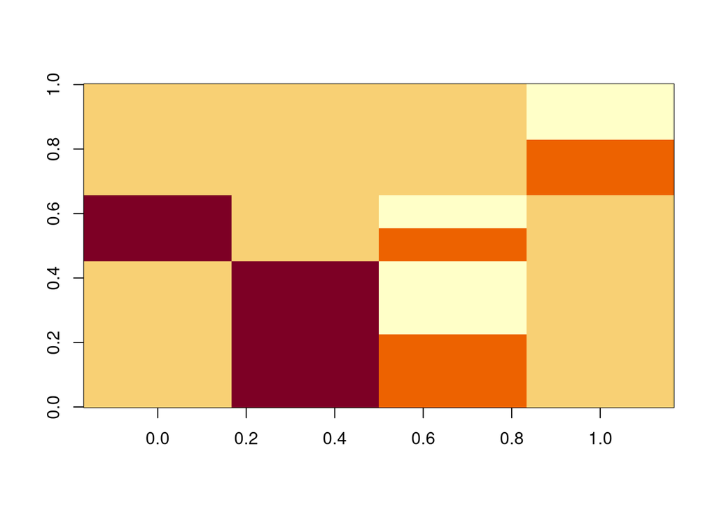

```r
# Priors
prior_prob_BB <- mean(ml&br < po)
prior_prob_CC <- mean(ml&br > po)

### CONTRAST C -----------------------------------------------------------------
make_condition_contrast_image(X_c)
```

```r
# (ml == br) </> po
mlbr_bd <- paste0('beta_', 3 + add_to_beta_index)
po_bd <- paste0('beta_', 4 + add_to_beta_index)

#  ML=BR < PO
pa_bigger_mlbr <- samp_out_c[,mlbr_bd] < samp_out_c[,po_bd]
post_prob_conBB <-
  mean(
    pa_bigger_mlbr
  )

#  ML=BR > PO
mlbr_bigger_pa <- samp_out_c[,mlbr_bd] > samp_out_c[,po_bd]
post_prob_conCC <-
  mean(
    mlbr_bigger_pa
  )
```

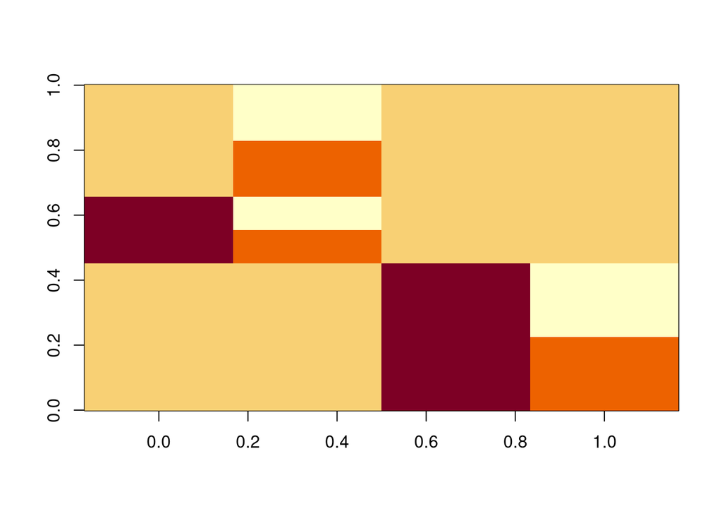

```r
# Priors
prior_prob_DD <- mean(ml&po < br)
prior_prob_EE <- mean(ml&po > br)

### CONTRAST D -----------------------------------------------------------------

make_condition_contrast_image(X_d)
```

```r
# (ml == po) </> br
mlpo_bd <- paste0('beta_', 2 + add_to_beta_index)
br_bd <- paste0('beta_', 4 + add_to_beta_index)

#  ML=PO < BR
ba_bigger_mlpa <- samp_out_d[, mlpo_bd] < samp_out_d[,br_bd]
post_prob_conDD <-
  mean(
    ba_bigger_mlpa
  )

#  ML=PO > BR
mlpa_bigger_ba <- samp_out_d[, mlpo_bd] > samp_out_d[,br_bd]
post_prob_conEE <-
  mean(
    mlpa_bigger_ba
  )
```

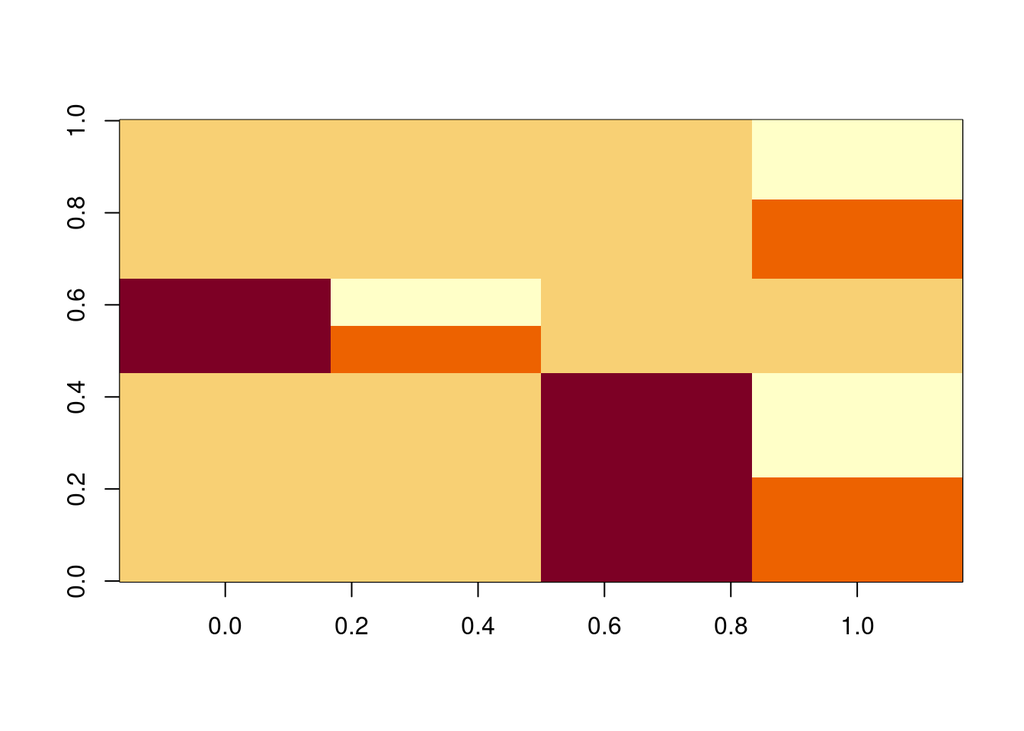

```r
# Priors
prior_prob_FF <- mean(br&po < ml)
prior_prob_GG <- mean(br&po > ml)


### CONTRAST L -----------------------------------------------------------------

make_condition_contrast_image(X_l)
```

```r
# (br == po) </> ml
ml_bd <- paste0('beta_', 2 + add_to_beta_index)
brpo_bd <- paste0('beta_', 4 + add_to_beta_index)

#  BR=PO < ML
ml_bigger_bapa <- samp_out_l[, brpo_bd] < samp_out_l[,ml_bd]
post_prob_conFF <-
  mean(
    ml_bigger_bapa
  )

#  BR=PO > ML
bapa_bigger_ml <- samp_out_l[, brpo_bd] > samp_out_l[,ml_bd]
post_prob_conGG <-
  mean(
    bapa_bigger_ml
  )
```

### Calculate ordinal BF

```r
# Unconstrained model
bf_uN <- bf_out_f$bf

# model A: effect on all conditions, no constrained across them
bf_A <- bf_out_a$bf
# model B: effect only in Payoff
bf_B <- bf_out_j$bf
# model C: effect only in Muller-Lyer
bf_C <- bf_out_e$bf
# model D: effect only in Base rate
bf_D <- bf_out_k$bf
# model E: effect in Payoff and Baserate, no effect in Muller-Lyer
bf_E <- bf_out_i$bf
# model F: effect in Payoff and Muller-Lyer, no effect in Baserate
bf_F <- bf_out_h$bf
# model G: effect in Muller-Lyer and Baserate, no effect in Payoff
bf_G <- bf_out_g$bf


# More-constrained models ---------------------------------

# model AA: BR = ML = PO
bf_AA <- bf_out_b$bf
# model BB: (ML = BR) < PO
bf_BB <- log(post_prob_conBB / prior_prob_BB) + bf_out_c$bf
# model CC: (ML = BR) > PO
bf_CC <- log(post_prob_conCC / prior_prob_CC) + bf_out_c$bf
# model DD: (ML = PO) < BR
bf_DD <- log(post_prob_conDD / prior_prob_DD) + bf_out_d$bf
# model EE: (ML = PO) > BR
bf_EE <- log(post_prob_conEE / prior_prob_EE) + bf_out_d$bf
# model FF: (BR = PO) < ML
bf_FF <- log(post_prob_conFF / prior_prob_FF) + bf_out_l$bf
# model GG: (BR = PO) > ML
bf_GG <- log(post_prob_conGG / prior_prob_GG) + bf_out_l$bf
# model HH (BR > ML < PO) & BR < PO
bf_HH <- log(post_prob_conHH / prior_prob_HH) + bf_out_a$bf
# model II (BR > ML < PO) & BR > PO
bf_II <- log(post_prob_conII / prior_prob_II) + bf_out_a$bf
# model JJ: (BR < ML > PO) & BR < PO
bf_JJ <- log(post_prob_conJJ / prior_prob_JJ) + bf_out_a$bf
# model KK: (BR < ML > PO) & BR > PO
bf_KK <- log(post_prob_conKK / prior_prob_KK) + bf_out_a$bf
# model LL: (BR < ML < PO) & PO > BR
bf_LL <- log(post_prob_conLL / prior_prob_LL) + bf_out_a$bf
# model MM: (BR > ML > PO) & PO < BR
bf_MM <- log(post_prob_conMM / prior_prob_MM) + bf_out_a$bf
```

## Make table with bf values

```r
bfs <-
  tribble(
    ~model, ~bf, ~model_label,
    'a', bf_A, 'BR&ML&PO',
    'b', bf_B, 'PO',
    'c', bf_C, 'ML',
    'd', bf_D, 'BR',
    'e', bf_E, 'BR & PO',
    'f', bf_F, 'ML & PO',
    'g', bf_G, 'BR & ML',
    # data-driven models
    'AA', bf_AA, 'BR = ML = PO',
    'BB', bf_BB, '(BR=ML) < PO',
    'CC', bf_CC, '(BR=ML) > PO',
    'DD', bf_DD, '(ML=PO) < BR',
    'EE', bf_EE, '(ML=PO) > BR',
    'FF', bf_FF, '(BR=PO) < ML',
    'GG', bf_GG, '(BR=PO) > ML',
    'HH', bf_HH, 'BR > ML < PO & BR < PO',
    'II', bf_II, 'BR > ML < PO & BR > PO',
    'JJ', bf_JJ, 'BR < ML > PO & BR < PO',
    'KK', bf_KK, 'BR < ML > PO & BR > PO',
    'LL', bf_LL, 'BR < ML < PO & BR < PO',
    'MM', bf_MM, 'BR > ML > PO & BR > PO',

    'UN', bf_uN, 'BR & ML & PO (no effect in all manipulations)'
  )


bfs %>%
  write_csv(here(sprintf(here('data/processed/rep_ordinal_models_bf_%s.csv'), task_name)))
```